**Исследование сетевых параметров публичных DNS серверов**

**Цель работы:**  
Проанализировать сетевые параметры публичных DNS серверов, сделать мотивированный вывод о предпочтительных серверах

**Исходные данные:**

| Устройство | Виртуальная машина | Операционная система |
| --- | --- | --- |
| Asus X541U Vivobook PC | VMware Workstation Pro 15 | Windows 10 |

**Используемое ПО:**

1. Rstudio IDE  
2. Traceroute/tracert  
3. Ping  
4. 2ip

**Исследуемые провайдеры DNS**

1. Google Public DNS  
2. Cloudflare DNS  
3. OpenDNS  
4. FLEX

**Варианты решения задачи**

1. Использовать утилиту tracert/traceroute(выберем этот вариант)  
2. Использовать ручной поиск, без утилит

**Общий план выполнения**

1. По исследуемым серверам собрать следующие данные:  
1.1.маршрут  
1.2.местоположение каждого узла маршрута к DNS-серверу  
1.3.организацию, владеющую каждым узлом маршрута к DNS-серверу  
1.4.среднюю RTT (round trip time) к DNS-серверу  
2. Выделить те узлы маршрута, которые вносят наибольшую временную задержку при передаче  
3. Сравнить сетевые параметры DNS серверов

**Ход работы**

**1.Google Public DNS**  
**Маршрут:**

```
 >tracert 8.8.8.8

Трассировка маршрута к dns.google [8.8.8.8]
с максимальным числом прыжков 30:

  1     3 ms    <1 мс    <1 мс  192.168.1.1
  2     2 ms     3 ms     2 ms  l2tp.flex.ru [10.255.255.254]
  3     4 ms     4 ms     3 ms  94.253.0.4
  4     6 ms     4 ms     5 ms  94.253.0.170
  5   132 ms     4 ms     4 ms  209.85.173.244
  6    49 ms     8 ms    31 ms  108.170.250.51
  7   112 ms    22 ms    22 ms  216.239.50.44
  8    18 ms    19 ms    18 ms  216.239.43.20
  9     *      119 ms    19 ms  216.239.47.165
 10     *        *        *     Превышен интервал ожидания для запроса.
 11     *        *        *     Превышен интервал ожидания для запроса.
 12     *        *        *     Превышен интервал ожидания для запроса.
 13     *        *        *     Превышен интервал ожидания для запроса.
 14     *        *        *     Превышен интервал ожидания для запроса.
 15     *        *        *     Превышен интервал ожидания для запроса.
 16     *        *        *     Превышен интервал ожидания для запроса.
 17     *        *        *     Превышен интервал ожидания для запроса.
 18     *        *        *     Превышен интервал ожидания для запроса.
 19    18 ms    18 ms    18 ms  dns.google [8.8.8.8]

Трассировка завершена.
```

**Среднее RTT:**

```
>ping 8.8.8.8

Обмен пакетами с 8.8.8.8 по с 32 байтами данных:
Ответ от 8.8.8.8: число байт=32 время=109мс TTL=46
Ответ от 8.8.8.8: число байт=32 время=166мс TTL=46
Ответ от 8.8.8.8: число байт=32 время=118мс TTL=46
Ответ от 8.8.8.8: число байт=32 время=121мс TTL=46

Статистика Ping для 8.8.8.8:
    Пакетов: отправлено = 4, получено = 4, потеряно = 0
    (0% потерь)
Приблизительное время приема-передачи в мс:
    Минимальное = 109мсек, Максимальное = 166 мсек, Среднее = 128 мсек
```

**Местоположение и организация:**

[output not shown]

**2.OpenDNS**  
**Маршрут:**

```
>tracert 208.67.222.222

Трассировка маршрута к resolver1.opendns.com [208.67.222.222]
с максимальным числом прыжков 30:

  1     1 ms     1 ms    <1 мс  192.168.1.1
  2    99 ms     2 ms     2 ms  l2tp.flex.ru [10.255.255.254]
  3     5 ms     6 ms     6 ms  94.253.0.4
  4     5 ms     4 ms     4 ms  noginsk-dc.moscow.flex.ru [80.252.128.72]
  5     5 ms     7 ms     5 ms  ae21.RT.MR.MSK.RU.retn.net [87.245.228.89]
  6   151 ms    51 ms    51 ms  ae10-11.RT.THV.PAR.FR.retn.net [87.245.232.252]
  7    50 ms    50 ms    49 ms  opendns.par.franceix.net [37.49.236.210]
  8    50 ms    50 ms    50 ms  resolver1.opendns.com [208.67.222.222]

Трассировка завершена.
```

**Среднее RTT:**

```
>ping 208.67.222.222

Обмен пакетами с 208.67.222.222 по с 32 байтами данных:
Ответ от 208.67.222.222: число байт=32 время=50мс TTL=57
Ответ от 208.67.222.222: число байт=32 время=49мс TTL=57
Ответ от 208.67.222.222: число байт=32 время=49мс TTL=57
Ответ от 208.67.222.222: число байт=32 время=49мс TTL=57

Статистика Ping для 208.67.222.222:
    Пакетов: отправлено = 4, получено = 4, потеряно = 0
    (0% потерь)
Приблизительное время приема-передачи в мс:
    Минимальное = 49мсек, Максимальное = 50 мсек, Среднее = 49 мсек
```

**Местоположение и организация:**

| № | Узел | Местоположение | Организация |  |  |  |  |  |
| --- | --- | --- | --- | --- | --- | --- | --- | --- |
| 1 | 192.168.1.1 | Россия, Ногинск | Роутер |  |  |  |  |  |
| 2 | l2tp.flex.ru [10.255.255.254] | Лос-Анжелес, США | IANA |  |  |  |  |  |
| 3 | 94.253.0.4 | Россия, Москва | Flex |  |  |  |  |  |
| 4 | noginsk-dc.moscow.flex.ru [80.252.128.72] | Россия, Ногинск | Flex |  |  |  |  |  |
| 5 | ae21.RT.MR.MSK.RU.retn.net [87.245.228.89] | Россия, Москва | ReTN |  |  |  |  |  |
| 6 | ae10-11.RT.THV.PAR.FR.retn.net [87.245.232.252] | США | ReTN’s Backbone |  |  |  |  |  |
| 7 | opendns.par.franceix.net [37.49.236.210] | Франция, Париж | FranceIX Paris Peering LAN |  |  |  |  |  |
| 8 | resolver1.opendns.com [208.67.222.222] | США, Сан-Франциско | Cisco OpenDNS, LLC |  |  |  |  |  |

**3.Cloudflare DNS**  
**Маршрут:**

```
>tracert 1.1.1.1

Трассировка маршрута к one.one.one.one [1.1.1.1]
с максимальным числом прыжков 30:

  1    56 ms     1 ms     1 ms  192.168.1.1
  2     4 ms     2 ms     3 ms  l2tp.flex.ru [10.255.255.254]
  3     5 ms     4 ms     9 ms  94.253.0.4
  4     5 ms     5 ms     4 ms  10.1.0.5
  5     5 ms     5 ms     8 ms  zapret-service [80.252.130.132]
  6     6 ms     5 ms     7 ms  zapret-service.m9.moscow.flex.ru [80.252.130.129]
  7     9 ms     7 ms     8 ms  msk-ix.cloudflare.com [195.208.209.7]
  8     6 ms     5 ms     5 ms  one.one.one.one [1.1.1.1]

Трассировка завершена.
```

**Среднее RTT:**

```
>ping 1.1.1.1

Обмен пакетами с 1.1.1.1 по с 32 байтами данных:
Ответ от 1.1.1.1: число байт=32 время=5мс TTL=59
Ответ от 1.1.1.1: число байт=32 время=5мс TTL=59
Ответ от 1.1.1.1: число байт=32 время=5мс TTL=59
Ответ от 1.1.1.1: число байт=32 время=5мс TTL=59

Статистика Ping для 1.1.1.1:
    Пакетов: отправлено = 4, получено = 4, потеряно = 0
    (0% потерь)
Приблизительное время приема-передачи в мс:
    Минимальное = 5мсек, Максимальное = 5 мсек, Среднее = 5 мсек
```

Наибольшая временная задержка не выявлена

**Местоположение и организация:**

| № | Узел | Местоположение | Организация |  |  |  |  |  |
| --- | --- | --- | --- | --- | --- | --- | --- | --- |
| 1 | 192.168.1.1 | Россия, Ногинск | Роутер |  |  |  |  |  |
| 2 | l2tp.flex.ru [10.255.255.254] | Лос-Анжелес, США | IANA |  |  |  |  |  |
| 3 | 94.253.0.4 | Россия, Москва | Flex |  |  |  |  |  |
| 4 | 10.1.0.5 | Лос-Анжелес, США | Internet Assigned Numbers Authority |  |  |  |  |  |
| 5 | zapret-service [80.252.130.132] | Россия, Ногинск | Flex |  |  |  |  |  |
| 6 | zapret-service.m9.moscow.flex.ru [80.252.130.129] | Россия, Ногинск | Flex |  |  |  |  |  |
| 7 | msk-ix.cloudflare.com [195.208.209.7] | Россия, Москва | - |  |  |  |  |  |
| 8 | one.one.one.one [1.1.1.1] | Австралия | APNIC and Cloudflare DNS Resolver project |  |  |  |  |  |

**4.Flex**  
**Маршрут:**

```
>tracert 80.252.130.253

Трассировка маршрута к ns3.flex.ru [80.252.130.253]
с максимальным числом прыжков 30:

  1     1 ms    <1 мс    <1 мс  192.168.1.1
  2     2 ms     2 ms     1 ms  l2tp.flex.ru [10.255.255.254]
  3     4 ms     4 ms     3 ms  94.253.0.4
  4     4 ms     3 ms     2 ms  ns3.flex.ru [80.252.130.253]

Трассировка завершена.
```

**Среднее RTT:**

```
>ping 80.252.130.253

Обмен пакетами с 80.252.130.253 по с 32 байтами данных:
Ответ от 80.252.130.253: число байт=32 время=4мс TTL=61
Ответ от 80.252.130.253: число байт=32 время=4мс TTL=61
Ответ от 80.252.130.253: число байт=32 время=3мс TTL=61
Ответ от 80.252.130.253: число байт=32 время=5мс TTL=61

Статистика Ping для 80.252.130.253:
    Пакетов: отправлено = 4, получено = 4, потеряно = 0
    (0% потерь)
Приблизительное время приема-передачи в мс:
    Минимальное = 3мсек, Максимальное = 5 мсек, Среднее = 4 мсек
```

**Местоположение и организация:**

| № | Узел | Местоположение | Организация |  |  |  |  |  |
| --- | --- | --- | --- | --- | --- | --- | --- | --- |
| 1 | 192.168.1.1 | Россия, Ногинск | Роутер |  |  |  |  |  |
| 2 | l2tp.flex.ru [10.255.255.254] | Лос-Анжелес, США | IANA |  |  |  |  |  |
| 3 | 94.253.0.4 | Россия, Москва | Flex |  |  |  |  |  |
| 4 | 80.252.130.253 | Россия, Ногинск | Flex |  |  |  |  |  |

**Сравнительная диаграмма**

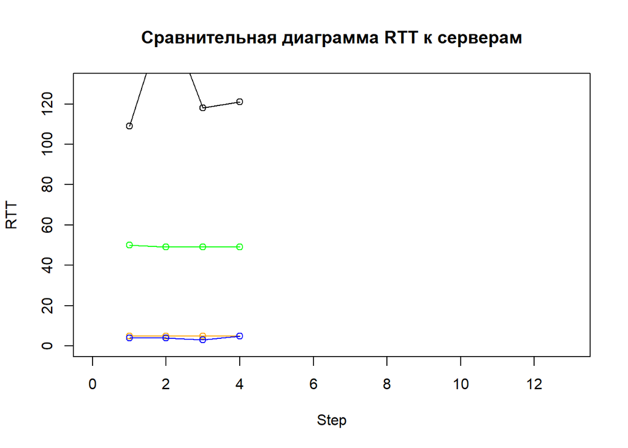

**Оценка результатов:**  
Меньше всего времени потребовалось для обмена пакетов для FLEX и Cloudflare DNS.

**Вывод:**  
Я познакомилась с DNS серверами,проанализировала их и научилась пользоваться утилитой tracert.